# Motion Project

#### Author - Arnie Larson

Project is part of a Coursera [Machine Learning](https://class.coursera.org/predmachlearn-034) class

HTML version available [here](https://arnielarson.github.io/analysis.html)

Coure Taught By: Jeff Leek, Johns Hopkins University

Date: 2015-11-19

#### Introduction

The goal of this project was to create a predictive model for classification of human motion data. The data set comes from a Human Activity Recognition [dataset](http://groupware.les.inf.puc-rio.br/har). The data used is from sensor captures of subjects doing a simple dumbell curl weightlifting exercise. Each capture is classified into 5 different ways one can *incorrectly* perform the exericse. For each capture sensors are used to record measurements of the dumbell/arm/waist etc. The authors used the time series nature of the data in their analysis to classify the motions. Our evaluation data is for *instants* in time. Since we do not have the entire timeseries in our evaluation data, the aim is to create a predictive model to classify the data from a single *instant*.

#### Project Overview

The objective is to classify the data for instants in time. The underlying structure of the data is a time series. I didn’t notice a lot of variation of the data vs. the window time, and so I removed the window time variable. I ultimately did not use any of the time or window information. I removed the columns that contain NA’s, e.g. all the summary statistics. I then tested several different modeling procedures with the [caret](http://topepo.github.io/caret/index.html) package. I separated my code out into functions in a few different files to ease reproduction. I did some explorartory analysis, plotting: data vs. window time, pair plots of data, and desnity plots. I didn’t really discern obvious patterns and correlations. The data seemed pretty noisy. So I used all the non-sparse raw data columns in my initial modeling transformed by a simple centering and scaling. As I began training models, I also saved models so that I could avoid retraining them later.

#### Data Overview

What’s in the Data? The data for the project includes a larger training set and a smaller evaluation data set.

- Training Data: 19622 rows, 160 columns, with 5 classifications
- Evaluation Data: 20 rows, 160 columns, not classified

#### Dataset Columns

- X, ordinal data, just the row number
- a user_name { 6 different people }
- new_window: yes/no - (yes is the **last** row for a given time window)
- num_window: ordinal, tracking the windows, also groups dataset
- raw_timestamp_part_1: unix time
- raw_timestamp_part_2: window time, presumed starting from 0 within a window
- cvtd_timestamp: a human readable time
- lots of data columns (accelerations, etc of arm/waist/dumbell etc..)
- data columns also include (sparse) summary statistics (min/max,mean,stdev)
- summary statistic data colums also contain !div/0
- classe { A -E } - the classification of each motion

#### Procedure:

To prepare the data, I removed the columns that I didn’t want to train on. Initially the column summemry statistics and later decided to remove the first 7 columns with user_name, time and windowing informaiton.

```r
source('process.R');
load_data()              # Loads data, creates pml global var
process(pml)        # Cuts the data, creates pmldata var
```

Let’s take a quick look at some of the pmldata variables.

```r
dim(pmldata); str(pmldata[,c(1,2,3,4,5,6,7,8,53)])
```

```
## [1] 19622    53
```

```
## 'data.frame':    19622 obs. of  9 variables:
##  $ roll_belt       : num  1.41 1.41 1.42 1.48 1.48 1.45 1.42 1.42 1.43 1.45 ...
##  $ pitch_belt      : num  8.07 8.07 8.07 8.05 8.07 8.06 8.09 8.13 8.16 8.17 ...
##  $ yaw_belt        : num  -94.4 -94.4 -94.4 -94.4 -94.4 -94.4 -94.4 -94.4 -94.4 -94.4 ...
##  $ total_accel_belt: int  3 3 3 3 3 3 3 3 3 3 ...
##  $ gyros_belt_x    : num  0 0.02 0 0.02 0.02 0.02 0.02 0.02 0.02 0.03 ...
##  $ gyros_belt_y    : num  0 0 0 0 0.02 0 0 0 0 0 ...
##  $ gyros_belt_z    : num  -0.02 -0.02 -0.02 -0.03 -0.02 -0.02 -0.02 -0.02 -0.02 0 ...
##  $ accel_belt_x    : int  -21 -22 -20 -22 -21 -21 -22 -22 -20 -21 ...
##  $ classe          : Factor w/ 5 levels "A","B","C","D",..: 1 1 1 1 1 1 1 1 1 1 ...
```

I found that looking at the covariance matrix gives us a quick and dirty view of the variables in the data set and a feel for the correlations. The plot indicates that there’s some, but pobably not a lot of very correlated data:

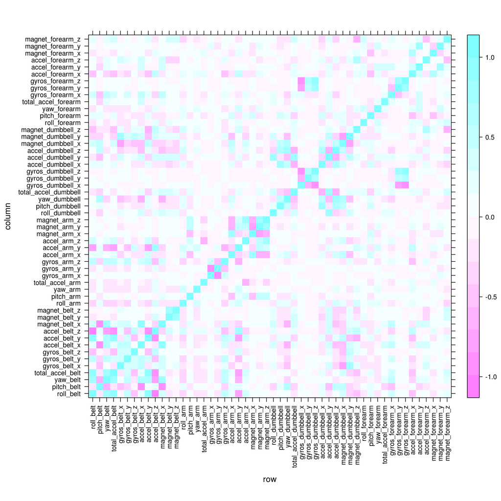

```r
library(lattice)
cv <- cov(scale(pmldata[,-53]))  # scale the data before getting the covariance
levelplot(cv, aspect="iso",  scales=list(x=list(rot=90)))
```

It can also be useful to visualize some of the variables with pair plottings. I did this for several types of variables that might have correlations. For example the dumbbell accelerations:

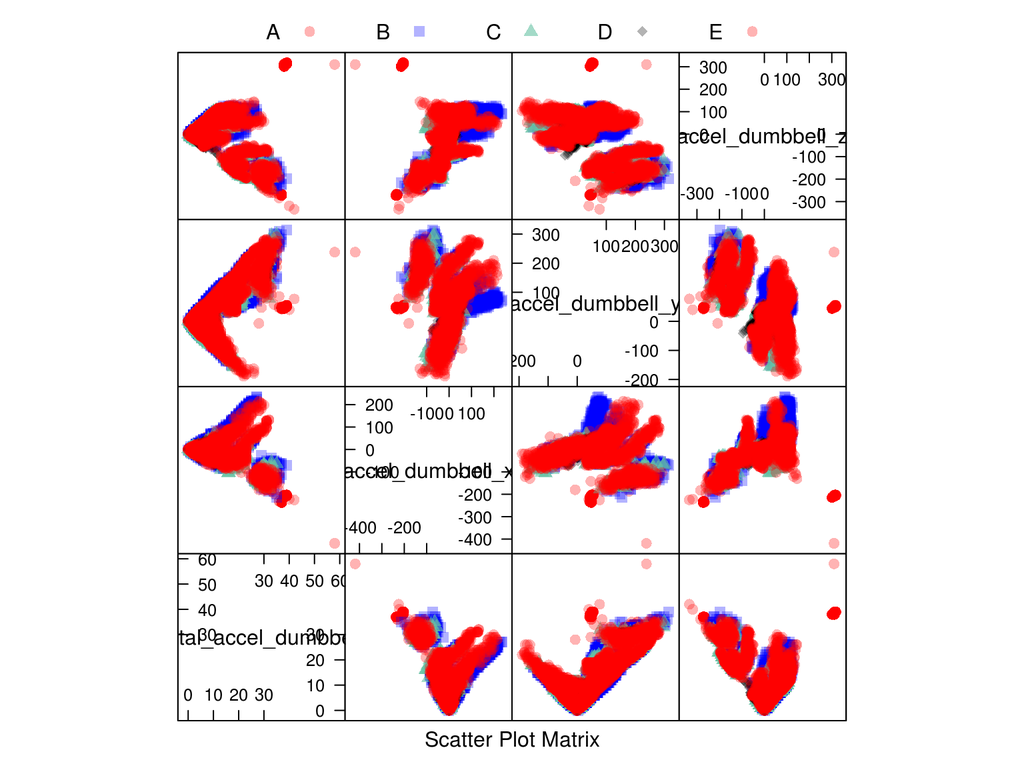

```r
library(caret)
library(AppliedPredictiveModeling)
transparentTheme(trans = .3)
accel_vars<-grep("accel_dumb",names(pmldata))
featurePlot(x=pmldata[,accel_vars],y=pmldata$classe,
            plot="pairs", auto.key=list(columns = 5))
```

There generally appeared to be a lot of overlap for the distinct classes for most of the independent variables. At this point I began trying to train some models with all of the data columns. I started by bifurcating the training data into a training and test set and attempted train several models on 20% of the training data. I then created a pre processing routine, using the entire data set for estimating the centering and scaling parameters.

```r
bifurcate(pmldata, p=0.2)     # create training and testing data partitions
pp<-preProcess(pmldata)       # default behaivor is to apply centering and scaling
# I also tried using PCA decompositions
pp2<-preProcess(pmldata, method=c("center","scale","pca"),thresh=.90)
pmltraint<-predict(pp,pmltraining)  # this actually applies the transformation
```

My model training routing used the method “cv” which caret uses to do a 5 fold cross validation on the input data to estimate the out of sample error. Very convenient.

```
ctrl=trainControl(method="cv",number=5)
mx <- train(classe ~ ., data=pmltraint, method="x",trControl=ctrl)
```

Once a model has been trained, it can be tested on the remaining data. The caret confusion matrix command is useful to get out of sample accuracy and a truth table with Type I and II errors.

```r
pmltestt<-predict(pp,pmltesting)  # transform the test data
confusionMatrix(pmltestt$classe, predict(mrf4, pmltestt))
```

```
## Confusion Matrix and Statistics
##
##           Reference
## Prediction    A    B    C    D    E
##          A 4455    3    5    0    1
##          B   36 2979   16    5    1
##          C    0   19 2708   10    0
##          D    0    0   27 2542    3
##          E    0    1    3   17 2864
##
## Overall Statistics
##
##                Accuracy : 0.9906
##                  95% CI : (0.989, 0.9921)
##     No Information Rate : 0.2861
##     P-Value [Acc > NIR] : < 2.2e-16
##
##                   Kappa : 0.9882
##  Mcnemar's Test P-Value : NA
##
## Statistics by Class:
##
##                      Class: A Class: B Class: C Class: D Class: E
## Sensitivity            0.9920   0.9923   0.9815   0.9876   0.9983
## Specificity            0.9992   0.9954   0.9978   0.9977   0.9984
## Pos Pred Value         0.9980   0.9809   0.9894   0.9883   0.9927
## Neg Pred Value         0.9968   0.9982   0.9961   0.9976   0.9996
## Prevalence             0.2861   0.1913   0.1758   0.1640   0.1828
## Detection Rate         0.2838   0.1898   0.1725   0.1620   0.1825
## Detection Prevalence   0.2844   0.1935   0.1744   0.1639   0.1838
## Balanced Accuracy      0.9956   0.9939   0.9896   0.9926   0.9983
```

#### Results

For my initial round of model training I used 20% of the training data on all 5 classes. I was only able to get Random Forest and Support Vector Machine models to work as expected and have reasonable accuracy. I found that a Support Vector Machine model w/ a Polynomial kernel with degree 3 had an accuracy on the testing data of ~ 93.4%. I found that Random Forest models had an accuracy of ~ 82%.

Next I trained models with 40% of the input data. I found, remarkably, that Random Forest models had improved to ~ 98.9% accuracy and that an SVM with polynomial kernel of degree 3 had ~98.3% accuracy. The SVM polynomial model also took about 42 minutes to train compared to less than 10 minutes for the Random Forest. I believe this is due to the SVM model trying out a larger variety of parameters and kernel degrees. I also trained a Random Forest model on the entire data set - this took about 38 minutes and estimated a training accuracy of 99.8%.

Estimates of out of sample error is important in any predictive analysis, and for this sale a simple k-fold cross validation is excellent. In caret this step can easily be incorporated in the model training process. I used a 5 fold cross validation during training.

##### Out of sample error rates:

The “good” models were applied to the 20 test cases in the evaluation set. The “good” models (those with accuracy of at least 98%) were in agreement on the classification.

The classifications I found on the evaluation set: - B A B A A E D B A A B C B A E E A B B B

I ultimately was able to get decent accuracy wihout using the window time or the person as a dummy variable. And ultimately was able to create models with an accuracy of around 99%.